# Screen Reading with OpenCV and Google Vision APIs

These days I'm doing some rowing again.

When I'm not rowing in a boat on the river, I use a Concept2 rowing machine at the gym (known as "the erg"). I am a bit of a nerd in all areas of my life (even sport where, sometimes, I am almost a jock) so I like to digitally log my workouts.

I find that the more convienient logging is, the more likely I am to consistently do it. Rowing on the water is automagically logged by my watch but for rowing on the erg I need to manually note the distances/speeds completed. There *are* apps that can do this, but they only connect to the more recent versions of the Concept2.

At the moment my process is a bit like this:

1. Finish rowing
2. Take photograph on phone of the rowing machine screen
3. Refer to photo later when updating log

I think it should be possible to eliminate step 3 by algorithmically recognising the numbers of interest in the photo

The workout summary screen always looks something a bit like this:

[figure not shown]

My first attempt just sent the whole image to Google's Cloud Vision API to use their OCR service. The results were not ideal; with the layout of the screen not quite being a table Google seem to struggle with knowing which order to present the text they recognise. E.g. the might group the totals/averages together (as I want) or they might group the time in with the column headings and the logo (which I don't want).

Here is a typical example:

[figure not shown]

This does suggest a plan of attack; if I can extract just the totals/averages from the image then Google's OCR service should be able to manage this quite well.

I'm going to do all this in python because the opencv python library seems to have better support/docs than other languages.

We'll start with some notebook settings and imports

```python
%matplotlib inline
import cv2 #the opencv library. Confusingly, on my system, this is installed as opencv3
import matplotlib.pyplot as plt #for displaying images
import imutils #convienient utils for resizing images
import numpy as np #an image is just an array of pixels
```

I also have a small number of photos for testing with (mostly stolen off Reddit)

```python
files = [
    "data/3w2u44.jpg",
    "data/3w5q2r_0.jpg", # this one is tricky
    "data/3w5q2r_1.jpg",
    "data/45f39n.jpg",
    "data/3xhso7.jpg",
    "data/3xipdn.jpg",
    "data/3z2ye2.jpg",
    "data/3zbv3t.jpg"
]

names = [
    "0","1","2","3","4","5","6","7"
]
```

I'll be doing stuff to these images and wanting to view the results so I'll make some quick functions to display all the screens in a grid.

[figure not shown]

```python
def sideBySidePlot(images):
    n = len(images)
    for i in range(0,n):
        x = plt.subplot(2,4,i+1)
        plt.imshow(images[i], cmap="Greys") #cmap="Greys" doesn't mean grayscale!
        plt.axis('off')
        x.set_title(names[i])

def columnPlot(images):
    n = len(images)
    plt.subplots(n,1,figsize=(15,15))
    for i in range(0,n):
        x = plt.subplot(n,1,i+1)
        plt.imshow(images[i], cmap="Greys")
        plt.axis('off')

# resize the images to a standard height
def readAndResizeImages(f):
  image = cv2.imread(f)
  ratio = image.shape[0] / 600.0
  image = imutils.resize(image, height = 600)
  return image

images = [readAndResizeImages(f) for f in files]
originals = [cv2.imread(f) for f in files]

sideBySidePlot(images)
```

Great! Now I can see what I'm working with.

The next step was hard! I want to just extract the screen bit from the photo (i.e. not the background and not the plastic surround). I tried a few different things which I will show you here just so you don't think that I'm some kind of genius for whom everything works first time.

The first thing I thought to try was to detect the edges of the screen.

[figure not shown]

```python
# Edge detection works on a grayscale image
grays = [cv2.cvtColor(image, cv2.COLOR_BGR2GRAY) for image in images]
# A Bilateral Filter smooths things out a bit so we won't detect noise as edges
grays = [cv2.bilateralFilter(gray, 9, 17, 17) for gray in grays]
sideBySidePlot(grays)
```

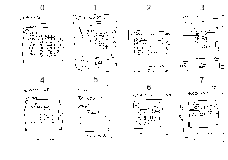

```python
# Canny is an edge detection algorithm
edged = [cv2.Canny(gray, 30, 200) for gray in grays]
sideBySidePlot(edged)
```

This does not look good! I hoped it would draw a rectangle around the screen.

The next thing to try is "contouring". If we can use a contour detection algorithm to find the edge of the screen this will also work.

Start by "thresholding" the image. This converts to two tone black and white

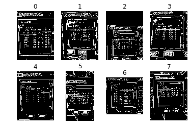

```python
thresholds = [cv2.adaptiveThreshold(gray,255,cv2.ADAPTIVE_THRESH_GAUSSIAN_C,
                            cv2.THRESH_BINARY,11,2) for gray in grays]
sideBySidePlot(thresholds)
```

For some images, this looks quite promising. For others (e.g. 1, 2 and 5) it still looks terrible.

Even the good images are quite "speckly". "Erode" the speckles away as if they are small islands of sand in a river

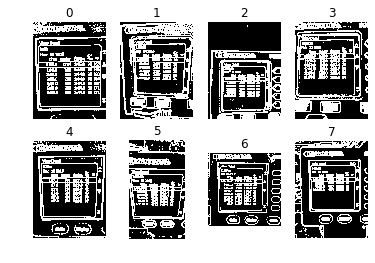

```python
kernel = np.ones((5,5),np.uint8) # how big and what shape the waves are
eroded = [cv2.erode(th,kernel,iterations = 1) for th in thresholds]
sideBySidePlot(eroded)
```

The opposite of erosion is dilation. By eroding and then dilating, speckles are removed during the first phase and "large islands" are joined together during the second. This should mean we end up with continuous lines on our thresholded images where continous lines existed in the originals.

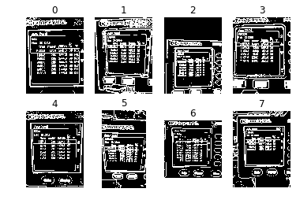

```python
kernel = np.ones((3,3),np.uint8)
dilated = [cv2.dilate(erode,kernel,iterations = 1) for erode in eroded]
sideBySidePlot(dilated)
```

This might be the right thing to do in theory, but it isn't looking very good in practice.

Find the contours anyway and draw the 10 largest

[figure not shown]

```python
def findBigContours(i):
  _, contours,_ = cv2.findContours(i.copy(),cv2.RETR_LIST,cv2.CHAIN_APPROX_SIMPLE )
  cnts = sorted(contours, key = cv2.contourArea, reverse = True)[:10]
  return(cnts)

cnts = [findBigContours(i) for i in dilated]
contourimages = [cv2.drawContours(i.copy(), c, -1, (0,255,0), 2) for (i,c) in zip(images,cnts)]

sideBySidePlot(contourimages)
```

Again, this doesn't look great but I'm going to keep going.

1. Approximate each contour with straight edges
2. Find the approximations that are rectangular
3. Take the largest one of these as the screen

[figure not shown]

```python
def findScreenCnt(cnts):
    screenCnt = None
    for c in cnts:
        peri = cv2.arcLength(c, True)
        approx = cv2.approxPolyDP(c, 0.04 * peri, True)
        if len(approx)==4 and cv2.isContourConvex(approx):
            screenCnt = approx
            break
    return screenCnt

screenContours = [findScreenCnt(cnt) for cnt in cnts]
screenimages = [cv2.drawContours(i.copy(), [c], -1, (0,255,0), 10) for (i,c) in zip(images,screenContours)]

sideBySidePlot(screenimages)
```

Have a closer look at images 1 and 7 which seem like they might be bad for different reasons.

[figure not shown]

[figure not shown]

```python
plt.imshow(screenimages[1])
plt.show()
plt.imshow(screenimages[7])
plt.show()
```

Both of these have some glare in the corner of the screen which might be causing problems with identifying the corners.

Let's have a closer look at the contours and compare with some other screens to see if this could be the case.

[figure not shown]

```python
plt.subplots(2,2,figsize=(15,15))

x = plt.subplot(2,2,1)
plt.imshow(contourimages[1])
plt.axis('off')
x.set_title("1")

x = plt.subplot(2,2,2)
plt.imshow(contourimages[7])
plt.axis('off')
x.set_title("7")

x = plt.subplot(2,2,3)
plt.imshow(contourimages[0])
plt.axis('off')
x.set_title("0")

x = plt.subplot(2,2,4)
plt.imshow(contourimages[6])
plt.axis('off')
x.set_title("6")

plt.show()
```

This doesn't really help me very much. Time to think of something different.

For a contour, we can find the smallest rectangle than completely contains the contour. The more "rectangular" a contour is, the closer the area enclosed within the contour is to the smallest bounding rectangle.

Because of the angle a photo is taken from and perspective etc. I can't ever expect a perfect rectangle, but perhaps there is a threshold I can use for filtering and selecting contours.

```python
def findContourSquareness(cnt):
  c_area = cv2.contourArea(cnt)
  rect = cv2.minAreaRect(cnt)
  r_area = cv2.contourArea( np.int0(cv2.boxPoints(rect)) )
  return c_area/r_area

[findContourSquareness(x) for x in screenContours]
```

```
[0.9730382315745771,
 0.9653738999690443,
 0.9483159362718168,
 0.9613461772954518,
 0.9514248302739199,
 0.9321428571428572,
 0.9883268265243311,
 0.7854230064461242]
```

A "rectangularness" of 90% looks like it might be good enough for now so rewrite the `findScreenCnt` function

[figure not shown]

```python
def findScreenCnt(cnts):
    screenCnt = None
    for c in cnts:
        peri = cv2.arcLength(c, True)
        approx = cv2.approxPolyDP(c, 0.04 * peri, True)
        if len(approx)==4 and cv2.isContourConvex(approx) and findContourSquareness(approx)>0.9:
            screenCnt = approx
            break
    return screenCnt

screenContours = [findScreenCnt(cnt) for cnt in cnts]
screenimages = [cv2.drawContours(i.copy(), [c], -1, (0,255,0), 10) for (i,c) in zip(images,screenContours)]

sideBySidePlot(screenimages)
```

This fixes things for number 7.

Another tweak to make is how rough an approximation we use for the contour. I'm just going to try a few different values here.

[figure not shown]

```python
def findScreenCntWithP(cnts,p):
    screenCnt = None
    for c in cnts:
        peri = cv2.arcLength(c, True)
        approx = cv2.approxPolyDP(c, p * peri, True)
        if len(approx)==4 and cv2.isContourConvex(approx) and findContourSquareness(approx)>0.9:
            screenCnt = approx
            break
    return screenCnt

def plotScreenCnts(cnts,p):
  screenContours = [findScreenCntWithP(cnt,p) for cnt in cnts]
  screenimages = [cv2.drawContours(i.copy(), ([c] if c is not None else []), -1, (0,255,0), 10) for (i,c) in zip(images,screenContours)]
  sideBySidePlot(screenimages)

plotScreenCnts(cnts,0.02)
```

[figure not shown]

```python
plotScreenCnts(cnts,0.03)
```

[figure not shown]

```python
plotScreenCnts(cnts,0.05)
```

`p=0.02` (approximating contour has 2% of the length of the real thing) works best for screen #2. Probably overfitting to use this but I'm going to stick with it for now and worry about that later.

```python
def findScreenCnt(cnts):
    screenCnt = None
    for c in cnts:
        peri = cv2.arcLength(c, True)
        approx = cv2.approxPolyDP(c, 0.02 * peri, True)
        if len(approx)==4 and cv2.isContourConvex(approx) and findContourSquareness(approx)>0.9:
            screenCnt = approx
            break
    return screenCnt

screenContours = [findScreenCnt(cnt) for cnt in cnts]
```

Another thing that the screens should have in common is the aspect ratio. What is resonable here?

```python
def aspectRatio(cnt):
    if cnt is not None:
      m = cv2.minAreaRect(cnt)
      return m[1][0]/m[1][1]
    else:
      return None

[aspectRatio(cnt) for cnt in screenContours]
```

```
[0.9981101953891471,
 None,
 0.9858196196485444,
 None,
 1.0476783634259934,
 0.8403463847243167,
 0.980510926880945,
 1.0189213393080452]
```

Allow values between 0.8 and 1.2.

With this check in place, the rectangularness check is probably redundant but leave it in anyway

[figure not shown]

```python
def findScreenCnt(cnts):
    screenCnt = None
    for c in cnts:
        peri = cv2.arcLength(c, True)
        approx = cv2.approxPolyDP(c, 0.02 * peri, True)
        try:
          aspect = aspectRatio(approx)
        except ZeroDivisionError:
          aspect = 10
        if len(approx)==4 and cv2.isContourConvex(approx) and findContourSquareness(approx)>0.9 and aspect > 0.8 and aspect < 1.2:
            screenCnt = approx
            break
    return screenCnt

screenContours = [findScreenCnt(cnt) for cnt in cnts]
screenimages = [cv2.drawContours(i.copy(), ([c] if c is not None else []), -1, (0,255,0), 10) for (i,c) in zip(images,screenContours)]

sideBySidePlot(screenimages)
```

Up to 6 out of 8 now and I'm able to say `None` for images 1 and 3 where no suitable contour is found.

As I've mentioned before, I think part of the problem with these images is the glare on the screen. My intuition is that this is the same colour as the rest of the screen but that the brightness is *way* higher. So if there was a way to only look at the colour of the pixels rather than the brightness this should make it easier to find the edgeof the screen.

Normally I think of colours as being defined by how much red, green and blue they contain (i.e. each pixel has 3 dimensions) but there are other ways of doing this. One way is called the [CIELAB colour space](https://en.wikipedia.org/wiki/CIELAB_color_space). This also has three numbers for each pixel; one is the lightness and the other two measure the amount of green-red and blue-yellow. I don't really know why this works, but the interesting thing is that this allows me to ignore the brightness and look only at the colour. In fact it is only necessary to look at one of the colour dimensions.

[figure not shown]

```python
def convertColour(img):
    cie = cv2.cvtColor(img, cv2.COLOR_BGR2LAB)
    red = cie[:,:,2] # doesn't actual mean red
    return(red)

sideBySidePlot([convertColour(i.copy()) for i in images])
```

Notice how screen glare is removed in images 1, 2 and 3 (the none backlit erg screens).

I can combine both approaches. First try the original `findScreenContour` and then, if not suitable contour is found change the colourspace and try again.

Because the function will need to change the colourspace, the full original image will have to be an input to the function. This gives and opportunity to formalise the pipeline a bit more at the same time

```
Found screen (prob. backlit)
Found screen (prob. not backlit)
Found screen (prob. not backlit)
Found screen (prob. not backlit)
Found screen (prob. backlit)
Found screen (prob. backlit)
Found screen (prob. backlit)
Found screen (prob. backlit)
```

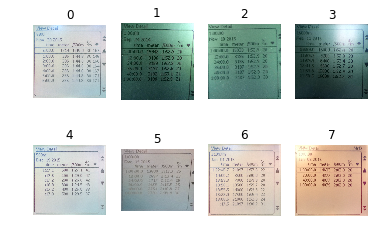

```python
def resizeTo600(img):
    return imutils.resize(img, height=600)

def toGrayscale(img):
    return cv2.cvtColor(img, cv2.COLOR_BGR2GRAY)

def bilateralFilter(img):
    return cv2.bilateralFilter(img, 9, 50, 50)

# otsu is a different way of thresholding
# slightly more complicated in that it thresholds based on 'local' brightness
# rather than 'global' thresholds for the whole image
# I'm using it here as another way to try and avoid problems with glare
def otsuThresh(img):
  _,thresh = cv2.threshold(img,0,255,cv2.THRESH_BINARY+cv2.THRESH_OTSU)
  return thresh

def findBigContours(i,n):
  _, contours,_ = cv2.findContours(i.copy(),cv2.RETR_LIST,cv2.CHAIN_APPROX_SIMPLE )
  cnts = sorted(contours, key = cv2.contourArea, reverse = True)[:n]
  cnts = [c for c in cnts if cv2.contourArea(c) > 0]
  return(cnts)

def findContourSquareness(cnt):
  c_area = cv2.contourArea(cnt)
  rect = cv2.minAreaRect(cnt)
  r_area = cv2.contourArea( np.int0(cv2.boxPoints(rect)) )
  return c_area/r_area

def aspectRatio(cnt):
    if cnt is not None:
      m = cv2.minAreaRect(cnt)
      return m[1][0]/m[1][1]
    else:
      return None

def findScreenCnt(cnts):
    screenCnt = None
    for c in cnts:
        peri = cv2.arcLength(c, True)
        approx = cv2.approxPolyDP(c, 0.02 * peri, True)
        try:
          aspect = aspectRatio(approx)
        except ZeroDivisionError:
          aspect = 10
        if len(approx)==4 and cv2.isContourConvex(approx) and findContourSquareness(approx)>0.9 and aspect > 0.8 and aspect < 1.2:
            screenCnt = approx
            break
    return screenCnt

# given a contour, this function extracts it from the image and warps it
# to be a rectangle.
# Taken from https://www.pyimagesearch.com/2014/05/05/building-pokedex-python-opencv-perspective-warping-step-5-6/
def extractScreenTransform(original, cnt):
    if cnt is None:
        return None
    ratio = original.shape[0] / 600.0
    pts = cnt.reshape(4, 2)
    rect = np.zeros((4, 2), dtype = "float32")
    # the top-left point has the smallest sum whereas the
    # bottom-right has the largest sum
    s = pts.sum(axis = 1)
    rect[0] = pts[np.argmin(s)]
    rect[2] = pts[np.argmax(s)]

    # compute the difference between the points -- the top-right
    # will have the minumum difference and the bottom-left will
    # have the maximum difference
    diff = np.diff(pts, axis = 1)
    rect[1] = pts[np.argmin(diff)]
    rect[3] = pts[np.argmax(diff)]

    # multiply the rectangle by the original ratio
    rect *= ratio
    (tl, tr, br, bl) = rect
    widthA = np.sqrt(((br[0] - bl[0]) ** 2) + ((br[1] - bl[1]) ** 2))
    widthB = np.sqrt(((tr[0] - tl[0]) ** 2) + ((tr[1] - tl[1]) ** 2))

    # ...and now for the height of our new image
    heightA = np.sqrt(((tr[0] - br[0]) ** 2) + ((tr[1] - br[1]) ** 2))
    heightB = np.sqrt(((tl[0] - bl[0]) ** 2) + ((tl[1] - bl[1]) ** 2))

    # take the maximum of the width and height values to reach
    # our final dimensions
    maxWidth = max(int(widthA), int(widthB))
    maxHeight = max(int(heightA), int(heightB))

    # construct our destination points which will be used to
    # map the screen to a top-down, "birds eye" view
    dst = np.array([
        [0, 0],
        [maxWidth - 1, 0],
        [maxWidth - 1, maxHeight - 1],
        [0, maxHeight - 1]], dtype = "float32")

    # calculate the perspective transform matrix and warp
    # the perspective to grab the screen
    M = cv2.getPerspectiveTransform(rect, dst)
    warp = cv2.warpPerspective(original, M, (maxWidth, maxHeight))
    return warp

# Finally put it all together
def extractScreen(img):
    original = img.copy()
    img = resizeTo600(img)
    gray = toGrayscale(img)
    bilat = bilateralFilter(gray)
    otsu = otsuThresh(bilat)
    cnts = findBigContours(otsu, 10)
    screenCnt = findScreenCnt(cnts)
    if screenCnt is not None:
        print( "Found screen (prob. backlit)")
        screen = extractScreenTransform(original, screenCnt)
        return screen
    else:
        cie = cv2.cvtColor(img, cv2.COLOR_BGR2LAB)
        red = cie[:,:,2]
        otsu = otsuThresh(red)
        cnts = findBigContours(otsu,10)
        screenCnt = findScreenCnt(cnts)
        if screenCnt is not None:
            print("Found screen (prob. not backlit)")
            screen = extractScreenTransform(original, screenCnt)
            return screen

screens = [extractScreen(i) for i in originals]

sideBySidePlot(screens)
```

Perfect 8/8 :-D

The next step is to extract the totals row from this image. I'll use the same techniques as before of finding rectangular contours with a particular aspect ratio and "rectangularness"

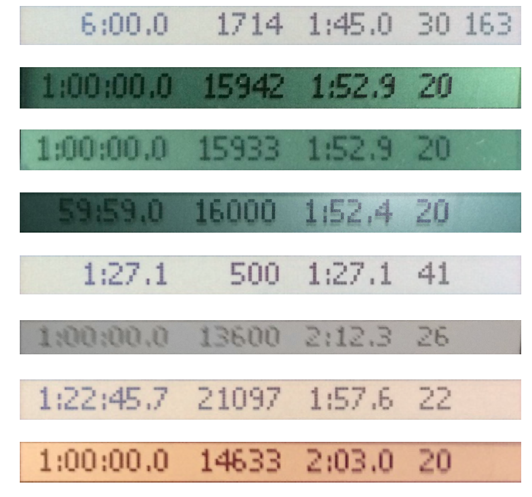

```python
# I expect much more uniform brightness in these images (i.e. no black containing plastic in front of white wall)
# So adaptive thresholding is a better choice than otsu
def adaptiveThresh(img):
  return cv2.adaptiveThreshold(img,255,cv2.ADAPTIVE_THRESH_MEAN_C,cv2.THRESH_BINARY,11,2)

def extractTotalRow(img):
    original = img.copy()
    img = resizeTo600(img)
    gray = toGrayscale(img)
    bilat = bilateralFilter(gray)
    adap = adaptiveThresh(bilat)
    cnts = findBigContours(adap, 20)
    filteredcnts = [c for c in cnts if (aspectRatio(c) < 0.1 or aspectRatio(c) > 10) and findContourSquareness(c) > 0.9]
    if len(filteredcnts) > 0:
        # if there are contours, pick the biggest one
        totalscnt = filteredcnts[0]
        box = cv2.boxPoints(cv2.minAreaRect(totalscnt))
        totals = extractScreenTransform(original,box)
        return totals
    else:
        # if there aren't apply a CLAHE filter to the image and try again
        clahe = cv2.createCLAHE()
        cl1 = clahe.apply(gray)
        otsu = otsuThresh(cl1)
        cnts = findBigContours(otsu, 20)
        filteredcnts = [c for c in cnts if aspectRatioNoRotation(c) < 0.1]
        if len(filteredcnts) > 0:
          totalscnt = filteredcnts[0]
          box = cv2.boxPoints(cv2.minAreaRect(totalscnt))
          totals = extractScreenTransform(original,box)
          return totals
        else:
            print("Unable to find totals row")
            return None

totals = [extractTotalRow(i) for i in screens]

totals = [i for i in totals if i is not None]

columnPlot(totals)
```

Works every time!

Here is what the code looks like to send these files to the OCR API and retrieve the result.

```
from google.cloud import storage
from google.cloud import vision
from google.cloud.vision.feature import Feature
from google.cloud.vision.feature import FeatureTypes
import os
import tempfile

os.environ["GOOGLE_APPLICATION_CREDENTIALS"] = "YOUR_CREDENTIALS.json"

def cloudAnalysis(filename):
    with tempfile.TemporaryDirectory() as tmpdirname:
        image = cv2.imread(filename)
        screen = extractScreen(image)
        totals = extractTotalRow(screen)
        totals_file = os.path.join(tmpdirname,filename + ".totals.jpg")
        cv2.imwrite(totals_file, totals)
        vision_client = vision.Client()
        with open(totals_file, 'rb') as image_file:
             image = vision_client.image(content=image_file.read())
        texts = image.detect_text()
        return texts

res = [cloudAnalysis(os.path.basename(f)) for f in files]
```

```python
# The above code isn't actually run, so you'll have to trust me that this is what res should be
res = ['6:00,0 1714 1:45.0\n30 163\n',
 '1:00:00.0 15942 1 52,9 20\n',
 '1 00:00,0 15933 1:52.9 20\n',
 '59:59.0 16000 1152,4 20\n',
 '1:27, 500 1:27, 41\n',
 '1:00:00.0 13600 2:12.3 26\n',
 '1:22:45,7 21097\n1:57.6 22\n',
 '1:00:00.0 14633\n2:03.0 20\n']
```

This isn't perfect, but it is structured enough that we should be able to do something with it.

First, replace some common errors

```python
res=[x.replace("\n"," ").replace(", ",".0 ").replace(",",".").strip() for x in res]
res
# is this overfitting? Quite possibly. The things I'm replacing can't appear
# in a totals row, but are the replacements legit?
```

```
['6:00.0 1714 1:45.0 30 163',
 '1:00:00.0 15942 1 52.9 20',
 '1 00:00.0 15933 1:52.9 20',
 '59:59.0 16000 1152.4 20',
 '1:27.0 500 1:27.0 41',
 '1:00:00.0 13600 2:12.3 26',
 '1:22:45.7 21097 1:57.6 22',
 '1:00:00.0 14633 2:03.0 20']
```

For ad-hoc parsing, I like to use the [Parsy](https://parsy.readthedocs.io/en/latest/overview.html) library

```python
from parsy import *

oneortwodigits = regex('[0-9]{1,2}').map(int).desc('1 or 2 digit')
onedigit = regex('[0-9]{1}').map(int).desc('1 digit')

parse_hours = seq(oneortwodigits.tag('hour'),
                 char_from(' :') >> oneortwodigits.tag('minute'),
                 char_from(' :') >> oneortwodigits.tag('second'),
                 char_from(' .') >> onedigit.tag('tenth')
                )
parse_minutes = seq(oneortwodigits.tag('minute'),
                 char_from(' :') >> oneortwodigits.tag('second'),
                 char_from(' .') >> onedigit.tag('tenth')
                )

parse_time = parse_hours | parse_minutes

parse_distance = regex('[0-9]{2,5}').map(int).desc('2-5 digit integer').tag('distance')

skip_split = any_char.times(6)

parse_rate = regex('[0-9]{2}').map(int).desc('2 digit rate').tag('rate')

parse_totals = seq(parse_time.map(dict).tag('time'),
                  any_char >> parse_distance,
                  any_char >> skip_split.tag(None),
                  any_char >> parse_rate).combine_dict(dict)

[parse_totals.parse_partial(x)[0] for x in res]
```

```
[{'time': {'minute': 6, 'second': 0, 'tenth': 0},
  'distance': 1714,
  'rate': 30},
 {'time': {'hour': 1, 'minute': 0, 'second': 0, 'tenth': 0},
  'distance': 15942,
  'rate': 20},
 {'time': {'hour': 1, 'minute': 0, 'second': 0, 'tenth': 0},
  'distance': 15933,
  'rate': 20},
 {'time': {'minute': 59, 'second': 59, 'tenth': 0},
  'distance': 16000,
  'rate': 20},
 {'time': {'minute': 1, 'second': 27, 'tenth': 0},
  'distance': 500,
  'rate': 41},
 {'time': {'hour': 1, 'minute': 0, 'second': 0, 'tenth': 0},
  'distance': 13600,
  'rate': 26},
 {'time': {'hour': 1, 'minute': 22, 'second': 45, 'tenth': 7},
  'distance': 21097,
  'rate': 22},
 {'time': {'hour': 1, 'minute': 0, 'second': 0, 'tenth': 0},
  'distance': 14633,
  'rate': 20}]
```

Excellent. I'm very pleased with this.